# The Armed Conflict in Colombia

Manuela Szinovatz

The following analysis is based on data from the Colombian governmental organisation Unidad Victimas, that is in charge of registering the victims of Colombia’s Armed Conflict. The data can be downloaded here: https://cifras.unidadvictimas.gov.co/

Up until October 2018 a total number of 8.760.290 victims were registered. Check out the table that lists the total number of violent incidents per year and find out which municipalities have been hit the hardest and when the conflict became particularly violent. Incidents reach from homicides, threats, torture, terroristic attacks and other kinds of violence. The grand majority of incidents are forced displacements.

|  | Municipality | Year | Incidents |
| --- | --- | --- | --- |
| 1 | Buenaventura | 2014 | 51688 |
| 2 | El Carmen De Bolivar | 2000 | 44118 |
| 3 | Buenaventura | 2013 | 39261 |
| 4 | Santa Marta | 2002 | 28644 |
| 5 | Sin Información | 2000 | 26201 |
| 6 | Buenaventura | 2011 | 25210 |
| 7 | Buenaventura | 2015 | 24192 |
| 8 | Buenaventura | 2012 | 23329 |
| 9 | El Charco | 2007 | 21882 |
| 10 | Valledupar | 2002 | 21339 |

[output cut: 19100 more lines]

## Violent Incidents

The following chart shows the overall number of incidents in Colombia’s most affected municipalities.

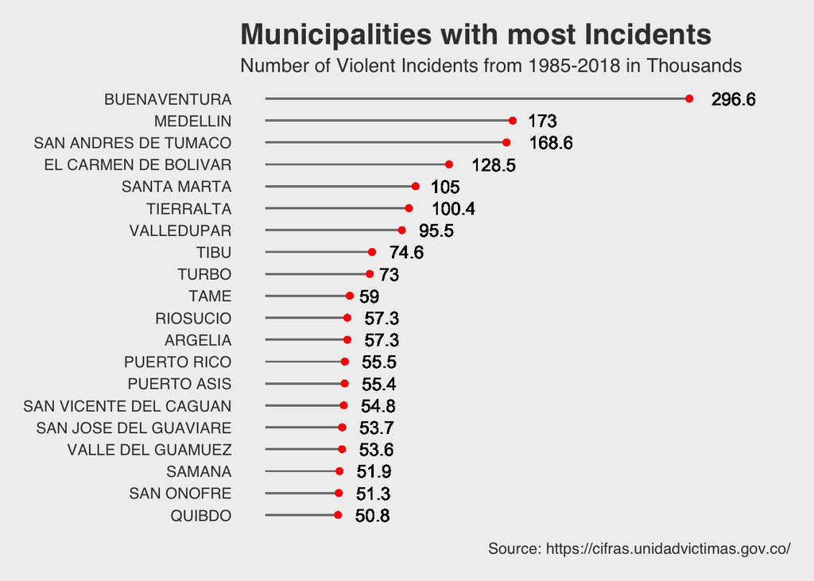

The following chart shows how these incidents in Buenaventura and Medellín have development over the last 33 years of conflict.

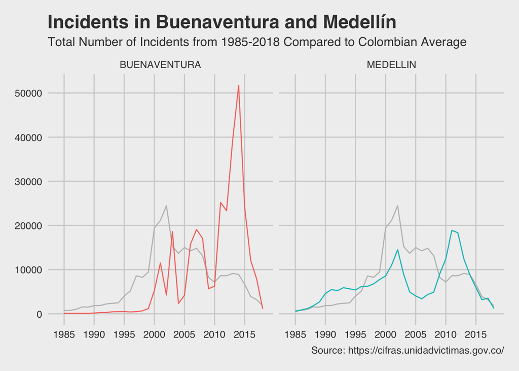